# HW4_Udayakumar_Balaji

Name: Balaji Udayakumar

Course: BUDT704

Section: 0503

Date: 10/20/2023

## Importing the required libraries

```python
import numpy as np
import seaborn as sns
import pandas as pd
import matplotlib.pyplot as plt
```

## Q1) Loading data from excel spreadsheet

## a) Loading the data from the file into a data frame with rank denoted as the index

```python
# # Setting the option to display all columns in the same partition
# pd.options.display.expand_frame_repr = False
# # Set display options to make output scrollable
# pd.set_option('display.max_columns', None)  # Display all columns
# pd.set_option('display.max_colwidth', None)  # Display full column width
# pd.set_option('display.expand_frame_repr', False)  # Prevent the frame from splitting

df = pd.read_excel('HW4_inc5000-2018.xlsx', index_col = 'RANK')
df.head()
```

| RANK | URL | CITY | GROWTH | EMPLOYEES | COMPANY NAME | WEBSITE | CITY.1 | STATE | REVENUW | ZIP CODE | FOUNDED | INDUSTRY | CITY, STATE | Unnamed: 14 | Unnamed: 15 |
| --- | --- | --- | --- | --- | --- | --- | --- | --- | --- | --- | --- | --- | --- | --- | --- |
| 1 | https://www.inc.com/profile/swanleap | Madison | 75660.8425 | 49 | SwanLeap | http://swanleap.com | Wisconsin | WI | 98965631 | 53719 | 2013.0 | Logistics & Transportation | Madison, WI | Makes software for the logistics industry that... | During stints as a freight broker and shipping... |
| 2 | https://www.inc.com/profile/popsockets | Boulder | 71423.7620 | 118 | PopSockets | http://popsockets.com | Colorado | CO | 168837562 | 80301 | 2010.0 | Consumer Products & Services | Boulder, CO | Makes self-adhesive, collapsible, expandable c... | Frustrated with his iPhone headphones getting ... |
| 3 | https://www.inc.com/profile/home-chef | Chicago | 60165.5058 | 865 | Home Chef | homechef.com | Illinois | IL | 255047839 | 60611 | 2013.0 | Food & Beverage | Chicago-Naperville-Elgin, IL-IN-WI | NaN | NaN |
| 4 | https://www.inc.com/profile/velocity-global | Denver | 39816.5093 | 55 | Velocity Global | http://velocityglobal.com | Colorado | CO | 49175942 | 80205 | 2013.0 | Business Products & Services | Denver-Aurora-Lakewood, CO | NaN | NaN |
| 5 | https://www.inc.com/profile/depcom-power | Scottsdale | 38962.9022 | 104 | DEPCOM Power | depcompower.com | Arizona | AZ | 219574136 | 85258 | 2013.0 | Energy | Phoenix-Mesa-Scottsdale, AZ | NaN | NaN |

## b) Printing the total number of companies on the list

```python
# Finding the total number of companies on the list by counting the length of the index
total_companies = len(df.index)
print("Total number of companies on the list:", total_companies)
```

```
Total number of companies on the list: 5000
```

## c) Printing a data frame containing companies ranked within the top 25

```python
# Printing a data frame containing companies ranked within the top 25
companies_by_rank_top_25 = df.head(25)
print("Top 25 companies with all data:")
companies_by_rank_top_25
```

```
Top 25 companies with all data:
```

| RANK | URL | CITY | GROWTH | EMPLOYEES | COMPANY NAME | WEBSITE | CITY.1 | STATE | REVENUW | ZIP CODE | FOUNDED | INDUSTRY | CITY, STATE | Unnamed: 14 | Unnamed: 15 |
| --- | --- | --- | --- | --- | --- | --- | --- | --- | --- | --- | --- | --- | --- | --- | --- |
| 1 | https://www.inc.com/profile/swanleap | Madison | 75660.8425 | 49 | SwanLeap | http://swanleap.com | Wisconsin | WI | 98965631 | 53719 | 2013.0 | Logistics & Transportation | Madison, WI | Makes software for the logistics industry that... | During stints as a freight broker and shipping... |
| 2 | https://www.inc.com/profile/popsockets | Boulder | 71423.7620 | 118 | PopSockets | http://popsockets.com | Colorado | CO | 168837562 | 80301 | 2010.0 | Consumer Products & Services | Boulder, CO | Makes self-adhesive, collapsible, expandable c... | Frustrated with his iPhone headphones getting ... |
| 3 | https://www.inc.com/profile/home-chef | Chicago | 60165.5058 | 865 | Home Chef | homechef.com | Illinois | IL | 255047839 | 60611 | 2013.0 | Food & Beverage | Chicago-Naperville-Elgin, IL-IN-WI | NaN | NaN |
| 4 | https://www.inc.com/profile/velocity-global | Denver | 39816.5093 | 55 | Velocity Global | http://velocityglobal.com | Colorado | CO | 49175942 | 80205 | 2013.0 | Business Products & Services | Denver-Aurora-Lakewood, CO | NaN | NaN |
| 5 | https://www.inc.com/profile/depcom-power | Scottsdale | 38962.9022 | 104 | DEPCOM Power | depcompower.com | Arizona | AZ | 219574136 | 85258 | 2013.0 | Energy | Phoenix-Mesa-Scottsdale, AZ | NaN | NaN |
| 6 | https://www.inc.com/profile/aeronux-airways | Marietta | 20005.2390 | 17 | Aeronux Airways | aeronux.com | Georgia | GA | 21874500 | 30066 | 2011.0 | Logistics & Transportation | Atlanta-Sandy Springs-Roswell, GA | NaN | NaN |
| 7 | https://www.inc.com/profile/diamond-assets | Milton | 19717.5129 | 41 | Diamond Assets | diamond-assets.com | Wisconsin | WI | 43084462 | 53563 | 2014.0 | Computer Hardware | Janesville, WI | NaN | NaN |
| 8 | https://www.inc.com/profile/gforce-life-sciences | Chicago | 16426.6575 | 13 | GForce Life Sciences | http://gforcestaff.com | Illinois | IL | 16893384 | 60606 | 2013.0 | Human Resources | Chicago-Naperville-Elgin, IL-IN-WI | NaN | NaN |
| 8 | https://www.inc.com/profile/flexport | San Francisco | 15911.2237 | 532 | Flexport | http://flexport.com | California | CA | 224745864 | 94102 | 2013.0 | Logistics & Transportation | San Francisco-Oakland-Hayward, CA | NaN | NaN |
| 9 | https://www.inc.com/profile/scientistcom | Solana Beach | 15267.7557 | 49 | Scientist.com | http://scientist.com | California | CA | 50268390 | 92075 | 2007.0 | Health | San Diego-Carlsbad, CA | NaN | NaN |
| 10 | https://www.inc.com/profile/the-garrett-companies | Greenwood | 14821.8995 | 40 | The Garrett Companies | http://thegarrettco.com | Indiana | IN | 82070447 | 46143 | 2014.0 | Real Estate | Indianapolis-Carmel-Anderson, IN | NaN | NaN |
| 11 | https://www.inc.com/profile/dgc-international | Vienna | 14475.5148 | 55 | DGC International | dgci.com | Virginia | VA | 179707790 | 22182 | 2010.0 | Government Services | Washington-Arlington-Alexandria, DC-VA-MD-WV | NaN | NaN |
| 12 | https://www.inc.com/profile/exabeam | San Mateo | 14032.4773 | 153 | Exabeam | exabeam.com | California | CA | 18781497 | 94403 | 2013.0 | Security | San Francisco-Oakland-Hayward, CA | NaN | NaN |
| 13 | https://www.inc.com/profile/podium | Lehi | 13645.2287 | 254 | Podium | podium.com | Utah | UT | 30248850 | 84043 | 2013.0 | Business Products & Services | Provo-Orem, UT | NaN | NaN |
| 14 | https://www.inc.com/profile/inova-us | Key Biscayne | 13135.1845 | 25 | Inova US | inovaus.com | Florida | FL | 39445482 | 33149 | 2008.0 | Advertising & Marketing | Miami-Fort Lauderdale-West Palm Beach, FL | NaN | NaN |
| 15 | https://www.inc.com/profile/adrizer | Sarasota | 12500.7218 | 24 | AdRizer | adrizer.com | Florida | FL | 16723552 | 34236 | 2013.0 | Software | Sarasota-Bradenton-Venice, FL | NaN | NaN |
| 16 | https://www.inc.com/profile/welfont | Tampa | 11359.3104 | 55 | Welfont | welfont.com | Florida | FL | 14055761 | 33602 | 2014.0 | Real Estate | Tampa-St. Petersburg-Clearwater, FL | NaN | NaN |
| 17 | https://www.inc.com/profile/thinx | New York City | 10924.1379 | 44 | THINX | shethinx.com | New York | NY | 39556922 | 10001 | 2014.0 | Retail | New York-Newark-Jersey City, NY-NJ-PA | NaN | NaN |
| 18 | https://www.inc.com/profile/draken-international | Lakeland | 10562.3592 | 200 | Draken International | drakenintl.com | Florida | FL | 30403184 | 33811 | 2011.0 | Government Services | Lakeland, FL | NaN | NaN |
| 19 | https://www.inc.com/profile/calmcom | San Francisco | 10548.7682 | 25 | Calm.com | calm.com | California | CA | 22347505 | 94105 | 2012.0 | Consumer Products & Services | San Francisco-Oakland-Hayward, CA | NaN | NaN |
| 20 | https://www.inc.com/profile/curate-partners | Stoneham | 10056.5729 | 13 | Curate Partners | curatepartners.com | Massachusetts | MA | 12328556 | 2180 | 2014.0 | Human Resources | Boston-Cambridge-Newton, MA-NH | NaN | NaN |
| 21 | https://www.inc.com/profile/figs | Los Angeles | 9947.5655 | 45 | FIGS | wearfigs.com | California | CA | 23115831 | 90064 | 2013.0 | Retail | Los Angeles-Long Beach-Anaheim, CA | NaN | NaN |
| 22 | https://www.inc.com/profile/techanax | Woodbridge | 9508.0119 | 20 | TechAnax | techanax.com | Virginia | VA | 24498797 | 22193 | 2012.0 | Government Services | Washington-Arlington-Alexandria, DC-VA-MD-WV | NaN | NaN |
| 24 | https://www.inc.com/profile/snacknation | Culver City | 9199.5777 | 158 | SnackNation | snacknation.com | California | CA | 16890172 | 90232 | 2014.0 | Food & Beverage | Los Angeles-Long Beach-Anaheim, CA | NaN | NaN |
| 25 | https://www.inc.com/profile/brooklinen | Brooklyn | 9154.1993 | 22 | Brooklinen | brooklinen.com | New York | NY | 47864847 | 11201 | 2014.0 | Retail | New York-Newark-Jersey City, NY-NJ-PA | NaN | NaN |

## Q2) Data Cleaning

### 1. Handling Missing Values

```python
# Counting the total number of nulls in each column and printing them
print(df.isnull().sum())

# Since the unnamed columns 14 and 15 have lot of null values, we are dropping those columns in the original dataframe
df.dropna(thresh = 24,axis = 1, inplace = True)
df.columns
```

```
URL                0
CITY               1
GROWTH             0
EMPLOYEES          0
COMPANY NAME       0
WEBSITE            0
CITY.1             1
STATE              1
REVENUW            0
ZIP CODE           0
FOUNDED            1
INDUSTRY           0
CITY, STATE       24
Unnamed: 14     4998
Unnamed: 15     4998
dtype: int64
```

```
Index(['URL', 'CITY', 'GROWTH', 'EMPLOYEES', 'COMPANY NAME', 'WEBSITE',
       'CITY.1', 'STATE', 'REVENUW', 'ZIP CODE', 'FOUNDED', 'INDUSTRY',
       'CITY, STATE'],
      dtype='object')
```

### 2. Splitting combined columns

```python
# Splitting CITY, STATE into two separate columns and dropping the concatenated columns

df[['CITY_GROUP', 'STATE_GROUP']] = df['CITY, STATE'].str.split(', ', expand=True)
df.drop('CITY, STATE', axis = 1, inplace = True)
df.head()
```

| RANK | URL | CITY | GROWTH | EMPLOYEES | COMPANY NAME | WEBSITE | CITY.1 | STATE | REVENUW | ZIP CODE | FOUNDED | INDUSTRY | CITY_GROUP | STATE_GROUP |
| --- | --- | --- | --- | --- | --- | --- | --- | --- | --- | --- | --- | --- | --- | --- |
| 1 | https://www.inc.com/profile/swanleap | Madison | 75660.8425 | 49 | SwanLeap | http://swanleap.com | Wisconsin | WI | 98965631 | 53719 | 2013.0 | Logistics & Transportation | Madison | WI |
| 2 | https://www.inc.com/profile/popsockets | Boulder | 71423.7620 | 118 | PopSockets | http://popsockets.com | Colorado | CO | 168837562 | 80301 | 2010.0 | Consumer Products & Services | Boulder | CO |
| 3 | https://www.inc.com/profile/home-chef | Chicago | 60165.5058 | 865 | Home Chef | homechef.com | Illinois | IL | 255047839 | 60611 | 2013.0 | Food & Beverage | Chicago-Naperville-Elgin | IL-IN-WI |
| 4 | https://www.inc.com/profile/velocity-global | Denver | 39816.5093 | 55 | Velocity Global | http://velocityglobal.com | Colorado | CO | 49175942 | 80205 | 2013.0 | Business Products & Services | Denver-Aurora-Lakewood | CO |
| 5 | https://www.inc.com/profile/depcom-power | Scottsdale | 38962.9022 | 104 | DEPCOM Power | depcompower.com | Arizona | AZ | 219574136 | 85258 | 2013.0 | Energy | Phoenix-Mesa-Scottsdale | AZ |

### 3. Replacing column name with the right name

```python
# Renaming column 'REVENUW' to 'REVENUE'
df.rename(columns={'REVENUW': 'REVENUE'}, inplace=True)
df.head()
```

| RANK | URL | CITY | GROWTH | EMPLOYEES | COMPANY NAME | WEBSITE | CITY.1 | STATE | REVENUE | ZIP CODE | FOUNDED | INDUSTRY | CITY_GROUP | STATE_GROUP |
| --- | --- | --- | --- | --- | --- | --- | --- | --- | --- | --- | --- | --- | --- | --- |
| 1 | https://www.inc.com/profile/swanleap | Madison | 75660.8425 | 49 | SwanLeap | http://swanleap.com | Wisconsin | WI | 98965631 | 53719 | 2013.0 | Logistics & Transportation | Madison | WI |
| 2 | https://www.inc.com/profile/popsockets | Boulder | 71423.7620 | 118 | PopSockets | http://popsockets.com | Colorado | CO | 168837562 | 80301 | 2010.0 | Consumer Products & Services | Boulder | CO |
| 3 | https://www.inc.com/profile/home-chef | Chicago | 60165.5058 | 865 | Home Chef | homechef.com | Illinois | IL | 255047839 | 60611 | 2013.0 | Food & Beverage | Chicago-Naperville-Elgin | IL-IN-WI |
| 4 | https://www.inc.com/profile/velocity-global | Denver | 39816.5093 | 55 | Velocity Global | http://velocityglobal.com | Colorado | CO | 49175942 | 80205 | 2013.0 | Business Products & Services | Denver-Aurora-Lakewood | CO |
| 5 | https://www.inc.com/profile/depcom-power | Scottsdale | 38962.9022 | 104 | DEPCOM Power | depcompower.com | Arizona | AZ | 219574136 | 85258 | 2013.0 | Energy | Phoenix-Mesa-Scottsdale | AZ |

## Q3) Adding region from states by region csv file

## a) Loading HW4_states_by_region.csv file to a dataframe

```python
# a. Load the data from the "HW4_states_by_region.csv" file into a data frame
states_by_region_df = pd.read_csv("HW4_states_by_region.csv")

states_by_region_df.head()
```

|  | State | State Code | Region | Division |
| --- | --- | --- | --- | --- |
| 0 | Alaska | AK | West | Pacific |
| 1 | Alabama | AL | South | East South Central |
| 2 | Arkansas | AR | South | West South Central |
| 3 | Arizona | AZ | West | Mountain |
| 4 | California | CA | West | Pacific |

## b) Creating and populating a 'Region' column using the data from the new data frame just created

```python
# b. Creating and populate the "Region" column in the company data frame
df.reset_index(inplace = True)

# Merging the two data frames using the "STATE" and "State Code" columns as the keys and performing a left join
df = df.merge(states_by_region_df, left_on="STATE", right_on="State Code", how="left")

# Dropping the duplicate "State Code" column
df.drop('State Code', axis = 1, inplace=True)

# Displaying the modified data frame with the "Region" column
df.head()
```

|  | RANK | URL | CITY | GROWTH | EMPLOYEES | COMPANY NAME | WEBSITE | CITY.1 | STATE | REVENUE | ZIP CODE | FOUNDED | INDUSTRY | CITY_GROUP | STATE_GROUP | State | Region | Division |
| --- | --- | --- | --- | --- | --- | --- | --- | --- | --- | --- | --- | --- | --- | --- | --- | --- | --- | --- |
| 0 | 1 | https://www.inc.com/profile/swanleap | Madison | 75660.8425 | 49 | SwanLeap | http://swanleap.com | Wisconsin | WI | 98965631 | 53719 | 2013.0 | Logistics & Transportation | Madison | WI | Wisconsin | Midwest | East North Central |
| 1 | 2 | https://www.inc.com/profile/popsockets | Boulder | 71423.7620 | 118 | PopSockets | http://popsockets.com | Colorado | CO | 168837562 | 80301 | 2010.0 | Consumer Products & Services | Boulder | CO | Colorado | West | Mountain |
| 2 | 3 | https://www.inc.com/profile/home-chef | Chicago | 60165.5058 | 865 | Home Chef | homechef.com | Illinois | IL | 255047839 | 60611 | 2013.0 | Food & Beverage | Chicago-Naperville-Elgin | IL-IN-WI | Illinois | Midwest | East North Central |
| 3 | 4 | https://www.inc.com/profile/velocity-global | Denver | 39816.5093 | 55 | Velocity Global | http://velocityglobal.com | Colorado | CO | 49175942 | 80205 | 2013.0 | Business Products & Services | Denver-Aurora-Lakewood | CO | Colorado | West | Mountain |
| 4 | 5 | https://www.inc.com/profile/depcom-power | Scottsdale | 38962.9022 | 104 | DEPCOM Power | depcompower.com | Arizona | AZ | 219574136 | 85258 | 2013.0 | Energy | Phoenix-Mesa-Scottsdale | AZ | Arizona | West | Mountain |

## Q4) Descriptive Stats:

## a) Providing descriptive statistics for revenue

```python
# a. Descriptive Statistics for Revenue
descriptive_stats_revenue = df['REVENUE']
min_revenue = descriptive_stats_revenue.min()
max_revenue = descriptive_stats_revenue.max()
median_revenue = descriptive_stats_revenue.median()
std_revenue = descriptive_stats_revenue.std()
print("Minimum Revenue:", min_revenue)
print("Maximum Revenue:", max_revenue)
print("Median Revenue:", median_revenue)
print("Revenue Standard Deviation:", std_revenue)
```

```
Minimum Revenue: 1952209
Maximum Revenue: 16433210000
Median Revenue: 9575009.5
Revenue Standard Deviation: 282990264.70188546
```

## b) Percentage of companies founded prior to 2015 have achieved revenue of at least $50 million

```python
# Filtering companies founded before 2015
founded_prior_to_2015 = df[df['FOUNDED'] < 2015]

# Creating a Boolean Series to identify companies with revenue over $50 million
boolean_revenue_over_50m = founded_prior_to_2015['REVENUE'] >= 50000000

# Further filtering the DataFrame to include only companies meeting the revenue criteria
filtered_revenue_over_50m = founded_prior_to_2015.loc[boolean_revenue_over_50m]

# Calculating the percentage of companies have achieved revenue of at least $50 million
# among all companies founded before 2015
percentage = (len(filtered_revenue_over_50m) / len(founded_prior_to_2015)) * 100

# Displaying the result with two decimal places
print(f"Percentage of companies founded before 2015 with revenue of at least $50 million: {percentage:.2f}%")
```

```
Percentage of companies founded before 2015 with revenue of at least $50 million: 13.62%
```

## c) Inferences that can be made based on observations

The Percentage of companies founded before 2015 with revenue of at least $50 million is 13.62%.

This could be because of the following factors:

- Business Model Success: They had likely developed successful and strong business models and strategies to generate consistent revenue and profit compared to rest of the other companies, which helped them cross the $50 million threshold.
- Resilience: Surviving and thriving in the business world for several years often requires adaptability and resilience. These companies may have weathered economic downturns, industry changes, and competition, indicating their ability to adapt to evolving circumstances which helped them generate higher revenues.

## Q5) A Python function with parameters of data frame, category, value, and a number that specifies the number of rows to display in the result.

```python
# Function to get the top n companies based on revenues for a specific value in the category

def top_n_companies(df, category=None, value=None, n=10):

    # Filtering the DataFrame if both category and value are provided
    if category is not None and value is not None:
        filtered_df = df[df[category] == value]
    # Else assigning back the original dataframe
    else:
        filtered_df = df

    # Sorting the filtered DataFrame by revenue in descending order and returning the top n rows
    sorted_df = filtered_df.sort_values(by='REVENUE', ascending=False).head(n)

    return sorted_df
```

## Q6) Creating dataframe for below questions

## a) The top fifteen overall companies

```python
df_top_15_companies = top_n_companies(df=df,n=15)
df_top_15_companies
```

|  | RANK | URL | CITY | GROWTH | EMPLOYEES | COMPANY NAME | WEBSITE | CITY.1 | STATE | REVENUE | ZIP CODE | FOUNDED | INDUSTRY | CITY_GROUP | STATE_GROUP | State | Region | Division |
| --- | --- | --- | --- | --- | --- | --- | --- | --- | --- | --- | --- | --- | --- | --- | --- | --- | --- | --- |
| 1287 | 1288 | https://www.inc.com/profile/prime-therapeutics | Eagan | 372.1123 | 4329 | Prime Therapeutics | primetherapeutics.com | Minnesota | MN | 16433210000 | 55121 | 1998.0 | Health | Minneapolis-St. Paul-Bloomington | MN-WI | Minnesota | Midwest | West North Central |
| 1317 | 1318 | https://www.inc.com/profile/allied-universal | Santa Ana | 363.0638 | 150000 | Allied Universal | aus.com | California | CA | 5301534000 | 92705 | 1965.0 | Security | Los Angeles-Long Beach-Anaheim | CA | California | West | Pacific |
| 4225 | 4226 | https://www.inc.com/profile/carahsoft-technology | Reston | 80.4559 | 900 | Carahsoft Technology | carahsoft.com | Virginia | VA | 4107537719 | 20190 | 2004.0 | Government Services | Washington-Arlington-Alexandria | DC-VA-MD-WV | Virginia | South | South Atlantic |
| 3438 | 3439 | https://www.inc.com/profile/endeavor | Beverly Hills | 110.9724 | 6200 | Endeavor | endeavorco.com | New York | NY | 3541178000 | 90210 | 1995.0 | Media | Los Angeles-Long Beach-Anaheim | CA | New York | Northeast | Middle Atlantic |
| 4340 | 4341 | https://www.inc.com/profile/drivetime | Tempe | 76.6689 | 6111 | DriveTime | drivetime.com | Arizona | AZ | 3267077000 | 85281 | 2002.0 | Consumer Products & Services | Phoenix-Mesa-Scottsdale | AZ | Arizona | West | Mountain |
| 4203 | 4204 | https://www.inc.com/profile/armada | Pittsburgh | 81.1360 | 468 | ARMADA | armada.net | Pennsylvania | PA | 2950772000 | 15238 | 1890.0 | Logistics & Transportation | Pittsburgh | PA | Pennsylvania | Northeast | Middle Atlantic |
| 3545 | 3546 | https://www.inc.com/profile/srs-distribution | McKinney | 106.2021 | 3132 | SRS Distribution | srsdistribution.com | Texas | TX | 2183778171 | 75070 | 2008.0 | Consumer Products & Services | Dallas-Fort Worth-Arlington | TX | Texas | South | West South Central |
| 2063 | 2064 | https://www.inc.com/profile/pinnacle-group | Dallas | 216.2477 | 1563 | Pinnacle Group | pinnacle1.com | Texas | TX | 2110176184 | 75240 | 1996.0 | Human Resources | Dallas-Fort Worth-Arlington | TX | Texas | South | West South Central |
| 4972 | 4973 | https://www.inc.com/profile/insight-global | Atlanta | 58.1746 | 2570 | Insight Global | insightglobal.com | Georgia | GA | 1928758851 | 30319 | 2001.0 | Business Products & Services | Atlanta-Sandy Springs-Roswell | GA | Georgia | South | South Atlantic |
| 3009 | 3010 | https://www.inc.com/profile/transportation-ins... | Hickory | 134.1974 | 510 | Transportation Insight | transportationinsight.com | North Carolina | NC | 1892660132 | 28602 | 1999.0 | Logistics & Transportation | Hickory-Lenoir-Morganton | NC | North Carolina | South | South Atlantic |
| 1387 | 1388 | https://www.inc.com/profile/victra | Raleigh | 341.3350 | 6000 | VICTRA | victra.com | North Carolina | NC | 1460373019 | 27615 | 1996.0 | Retail | Raleigh-Cary | NC | North Carolina | South | South Atlantic |
| 3495 | 3496 | https://www.inc.com/profile/strike | The Woodlands | 107.8916 | 5939 | Strike | strikeusa.com | Texas | TX | 1401259860 | 77380 | 2003.0 | Energy | Houston-The Woodlands-Sugar Land | TX | Texas | South | West South Central |
| 4550 | 4551 | https://www.inc.com/profile/avella-specialty-p... | Phoenix | 71.2137 | 706 | Avella Specialty Pharmacy | avella.com | Arizona | AZ | 1351981297 | 85085 | 1996.0 | Health | Phoenix-Mesa-Scottsdale | AZ | Arizona | West | Mountain |
| 2109 | 2110 | https://www.inc.com/profile/jeunesse-global | Lake Mary | 210.2303 | 825 | Jeunesse Global | jeunesseglobal.com | Florida | FL | 1300731294 | 32746 | 2009.0 | Consumer Products & Services | Orlando-Kissimmee-Sanford | FL | Florida | South | South Atlantic |
| 4986 | 4987 | https://www.inc.com/profile/pacific-dental-ser... | Irvine | 57.6902 | 9008 | Pacific Dental Services | pacificdentalservices.com | California | CA | 1186683500 | 92614 | 1994.0 | Health | Los Angeles-Long Beach-Anaheim | CA | California | West | Pacific |

## b) The top ten companies in the food and beverage industry

```python
df_top_10_Food_Beverage_companies = top_n_companies(df=df,category = 'INDUSTRY', value = 'Food & Beverage')
df_top_10_Food_Beverage_companies
```

|  | RANK | URL | CITY | GROWTH | EMPLOYEES | COMPANY NAME | WEBSITE | CITY.1 | STATE | REVENUE | ZIP CODE | FOUNDED | INDUSTRY | CITY_GROUP | STATE_GROUP | State | Region | Division |
| --- | --- | --- | --- | --- | --- | --- | --- | --- | --- | --- | --- | --- | --- | --- | --- | --- | --- | --- |
| 3756 | 3757 | https://www.inc.com/profile/jersey-mikes-subs | Manasquan | 97.4898 | 19000 | Jersey Mike's Subs | jerseymikes.com | New Jersey | NJ | 974782877 | 8736 | 1956.0 | Food & Beverage | New York-Newark-Jersey City | NY-NJ-PA | New Jersey | Northeast | Middle Atlantic |
| 3482 | 3483 | https://www.inc.com/profile/monogram-foods | Memphis | 108.5890 | 2700 | Monogram Foods | monogramfoods.com | Tennessee | TN | 670665838 | 38117 | 2004.0 | Food & Beverage | Memphis | TN | Tennessee | South | East South Central |
| 997 | 998 | https://www.inc.com/profile/gps-hospitality | Atlanta | 493.1933 | 11016 | GPS Hospitality | gpshospitality.com | Georgia | GA | 551176689 | 30328 | 2012.0 | Food & Beverage | Atlanta-Sandy Springs-Roswell | GA | Georgia | South | South Atlantic |
| 3433 | 3434 | https://www.inc.com/profile/freddys-frozen-cus... | Wichita | 111.0822 | 11886 | Freddy's Frozen Custard & Steakburgers | freddysusa.com | Kansas | KS | 410993763 | 67206 | 2002.0 | Food & Beverage | Wichita | KS | Kansas | Midwest | West North Central |
| 4060 | 4061 | https://www.inc.com/profile/blount-fine-foods | Fall River | 86.0419 | 628 | Blount Fine Foods | blountfinefoods.com | Massachusetts | MA | 338254000 | 1760 | 1946.0 | Food & Beverage | Boston-Cambridge-Newton | MA-NH | Massachusetts | Northeast | New England |
| 2 | 3 | https://www.inc.com/profile/home-chef | Chicago | 60165.5058 | 865 | Home Chef | homechef.com | Illinois | IL | 255047839 | 60611 | 2013.0 | Food & Beverage | Chicago-Naperville-Elgin | IL-IN-WI | Illinois | Midwest | East North Central |
| 3536 | 3537 | https://www.inc.com/profile/coopers-hawk-winer... | Countryside | 106.4360 | 4155 | Cooper's Hawk Winery & Restaurants | chwinery.com | Illinois | IL | 241827341 | 60525 | 2005.0 | Food & Beverage | Chicago-Naperville-Elgin | IL-IN-WI | Illinois | Midwest | East North Central |
| 2435 | 2436 | https://www.inc.com/profile/nothing-bundt-cakes | Addison | 177.5477 | 230 | Nothing Bundt Cakes | nothingbundtcakes.com | Texas | TX | 220026175 | 75001 | 1997.0 | Food & Beverage | Dallas-Fort Worth-Arlington | TX | Texas | South | West South Central |
| 514 | 515 | https://www.inc.com/profile/mod-pizza | Bellevue | 979.4089 | 5500 | MOD Pizza | modpizza.com | Washington | WA | 219487000 | 98008 | 2008.0 | Food & Beverage | Seattle-Tacoma-Bellevue | WA | Washington | West | Pacific |
| 4632 | 4633 | https://www.inc.com/profile/studio-movie-grill | Dallas | 68.3820 | 5800 | Studio Movie Grill | studiomoviegrill.com | Texas | TX | 211683327 | 75251 | 2000.0 | Food & Beverage | Dallas-Fort Worth-Arlington | TX | Texas | South | West South Central |

## c) The top three companies located in New York City

```python
df_top_3_companies_new_york = top_n_companies(df=df,category = 'CITY', value = 'New York City', n=3)
df_top_3_companies_new_york
```

|  | RANK | URL | CITY | GROWTH | EMPLOYEES | COMPANY NAME | WEBSITE | CITY.1 | STATE | REVENUE | ZIP CODE | FOUNDED | INDUSTRY | CITY_GROUP | STATE_GROUP | State | Region | Division |
| --- | --- | --- | --- | --- | --- | --- | --- | --- | --- | --- | --- | --- | --- | --- | --- | --- | --- | --- |
| 4854 | 4855 | https://www.inc.com/profile/sterling-talent-so... | New York City | 61.7196 | 4087 | Sterling Talent Solutions | sterlingtalentsolutions.com | New York | NY | 480956135 | 10004 | 1975.0 | Business Products & Services | New York-Newark-Jersey City | NY-NJ-PA | New York | Northeast | Middle Atlantic |
| 70 | 71 | https://www.inc.com/profile/compass | New York City | 4309.0950 | 464 | Compass | compass.com | New York | NY | 370560142 | 10011 | 2012.0 | Real Estate | New York-Newark-Jersey City | NY-NJ-PA | New York | Northeast | Middle Atlantic |
| 96 | 97 | https://www.inc.com/profile/peloton | New York City | 3710.7823 | 872 | Peloton | onepeloton.com | New York | NY | 328337000 | 10001 | 2012.0 | Retail | New York-Newark-Jersey City | NY-NJ-PA | New York | Northeast | Middle Atlantic |

## d) The top five companies in Maryland

```python
df_top_5_companies_Maryland = top_n_companies(df=df,category = 'STATE', value = 'MD', n=5)
df_top_5_companies_Maryland
```

|  | RANK | URL | CITY | GROWTH | EMPLOYEES | COMPANY NAME | WEBSITE | CITY.1 | STATE | REVENUE | ZIP CODE | FOUNDED | INDUSTRY | CITY_GROUP | STATE_GROUP | State | Region | Division |
| --- | --- | --- | --- | --- | --- | --- | --- | --- | --- | --- | --- | --- | --- | --- | --- | --- | --- | --- |
| 3356 | 3357 | https://www.inc.com/profile/infiniti-hr | Burtonsville | 115.2400 | 34499 | INFINITI HR | infinitihr.com | Maryland | MD | 371942140 | 20866 | 2008.0 | Human Resources | Washington-Arlington-Alexandria | DC-VA-MD-WV | Maryland | South | South Atlantic |
| 348 | 349 | https://www.inc.com/profile/t-rex-solutions | Greenbelt | 1427.5775 | 385 | T-Rex Solutions | trexsolutionsllc.com | Maryland | MD | 195539254 | 20770 | 1999.0 | Government Services | Washington-Arlington-Alexandria | DC-VA-MD-WV | Maryland | South | South Atlantic |
| 3195 | 3196 | https://www.inc.com/profile/the-maryland-and-d... | Salisbury | 122.8835 | 30 | The Maryland and Delaware Group of Long and Fo... | easternshorehomesolutions.com | Maryland | MD | 106544544 | 21801 | 2014.0 | Real Estate | Salisbury | MD | Maryland | South | South Atlantic |
| 1731 | 1732 | https://www.inc.com/profile/n2grate | Greenbelt | 263.3315 | 44 | n2grate | n2grate.com | Maryland | MD | 101674761 | 20770 | 2010.0 | Government Services | Washington-Arlington-Alexandria | DC-VA-MD-WV | Maryland | South | South Atlantic |
| 2076 | 2077 | https://www.inc.com/profile/tista-science-and-... | Rockville | 214.2944 | 296 | TISTA Science and Technology | tistatech.com | Maryland | MD | 95475617 | 20854 | 2005.0 | Government Services | Washington-Arlington-Alexandria | DC-VA-MD-WV | Maryland | South | South Atlantic |

## Q7) Awarding companies in industries with the name "Services" in it based on their revenues

- The top quarter of these companies were given a Trailblazer award
- The companies who didn't make the top quarter, but made the top half were given a Pioneer award
- Finally, a data frame showing the company, its rank, its revenue, and which award it will earn, sorted by revenue in descending order is displayed.

```python
# Identifying companies in service industries
service_companies = df.loc[df['INDUSTRY'].str.contains("Services", case=False, na=False)]
service_companies.head()
```

|  | RANK | URL | CITY | GROWTH | EMPLOYEES | COMPANY NAME | WEBSITE | CITY.1 | STATE | REVENUE | ZIP CODE | FOUNDED | INDUSTRY | CITY_GROUP | STATE_GROUP | State | Region | Division |
| --- | --- | --- | --- | --- | --- | --- | --- | --- | --- | --- | --- | --- | --- | --- | --- | --- | --- | --- |
| 1 | 2 | https://www.inc.com/profile/popsockets | Boulder | 71423.7620 | 118 | PopSockets | http://popsockets.com | Colorado | CO | 168837562 | 80301 | 2010.0 | Consumer Products & Services | Boulder | CO | Colorado | West | Mountain |
| 3 | 4 | https://www.inc.com/profile/velocity-global | Denver | 39816.5093 | 55 | Velocity Global | http://velocityglobal.com | Colorado | CO | 49175942 | 80205 | 2013.0 | Business Products & Services | Denver-Aurora-Lakewood | CO | Colorado | West | Mountain |
| 11 | 11 | https://www.inc.com/profile/dgc-international | Vienna | 14475.5148 | 55 | DGC International | dgci.com | Virginia | VA | 179707790 | 22182 | 2010.0 | Government Services | Washington-Arlington-Alexandria | DC-VA-MD-WV | Virginia | South | South Atlantic |
| 13 | 13 | https://www.inc.com/profile/podium | Lehi | 13645.2287 | 254 | Podium | podium.com | Utah | UT | 30248850 | 84043 | 2013.0 | Business Products & Services | Provo-Orem | UT | Utah | West | Mountain |
| 18 | 18 | https://www.inc.com/profile/draken-international | Lakeland | 10562.3592 | 200 | Draken International | drakenintl.com | Florida | FL | 30403184 | 33811 | 2011.0 | Government Services | Lakeland | FL | Florida | South | South Atlantic |

```python
# Calculate revenue partition for service companies to award them accordingly
revenue_partitions = service_companies['REVENUE'].quantile([0.75, 0.5])
top_quarter_threshold = revenue_partitions[0.75]
top_half_threshold = revenue_partitions[0.5]

trailblazer_award_condition = service_companies['REVENUE'] >= top_quarter_threshold

# Making a copy of the slice and assigning it to trailblazer_service_companies before modifying it
trailblazer_service_companies = service_companies.loc[trailblazer_award_condition].copy()

# Update the 'AWARD' column in the copy
trailblazer_service_companies['AWARD'] = 'Trailblazer'

pioneer_award_condition = (service_companies['REVENUE'] >= top_half_threshold) & (service_companies['REVENUE'] < top_quarter_threshold)

# Making a copy of the slice and assigning it to pioneer_service_companies before modifying it
pioneer_service_companies = service_companies.loc[pioneer_award_condition].copy()

# Updating the 'AWARD' column in the copy
pioneer_service_companies['AWARD'] = 'Pioneer'

# Concatenating the two DataFrames along rows
concatenated_service_companies = pd.concat([trailblazer_service_companies, pioneer_service_companies])

# Creating a data frame with company name, rank, revenue, and award
award_data = concatenated_service_companies[['COMPANY NAME', 'RANK', 'REVENUE', 'AWARD']]

# Sorting the data frame by revenue in descending order
award_data = award_data.sort_values(by='REVENUE', ascending=False)

award_data
```

|  | COMPANY NAME | RANK | REVENUE | AWARD |
| --- | --- | --- | --- | --- |
| 4225 | Carahsoft Technology | 4226 | 4107537719 | Trailblazer |
| 4340 | DriveTime | 4341 | 3267077000 | Trailblazer |
| 3545 | SRS Distribution | 3546 | 2183778171 | Trailblazer |
| 4972 | Insight Global | 4973 | 1928758851 | Trailblazer |
| 2109 | Jeunesse Global | 2110 | 1300731294 | Trailblazer |
| ... | ... | ... | ... | ... |
| 2550 | Rastaclat | 2551 | 9544805 | Pioneer |
| 284 | 2M Research | 285 | 9540000 | Pioneer |
| 1301 | Language on Demand | 1302 | 9529200 | Pioneer |
| 4329 | Next Day Dumpsters | 4330 | 9504000 | Pioneer |
| 1435 | Full Circle Home | 1436 | 9492423 | Pioneer |

639 rows × 4 columns

## Q8) Visualization 1

- A bar chart to visualize the distribution of count of companies by top 10 industries

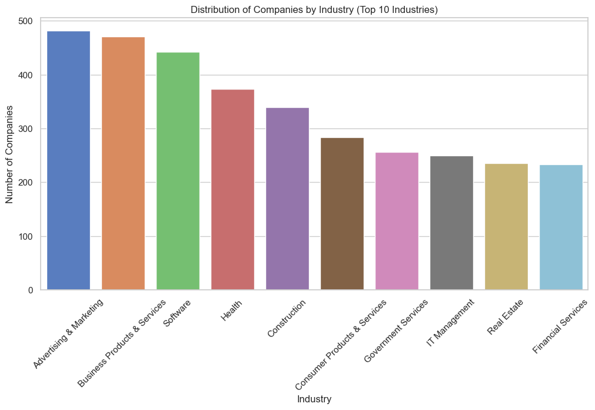

```python
import seaborn as sns
import matplotlib.pyplot as plt

# Counting the number of companies in each industry (top 10 industries)
top_10_industries = df['INDUSTRY'].value_counts().head(10)

# Creating a seaborn bar plot to visualize the distribution of companies by industry
plt.figure(figsize=(12, 6))
sns.set(style="whitegrid")  # Setting style
sns.barplot(x=top_10_industries.index, y=top_10_industries.values, palette="muted")
plt.title('Distribution of Companies by Industry (Top 10 Industries)')
plt.xlabel('Industry')
plt.ylabel('Number of Companies')
plt.xticks(rotation=45)  # Rotating horizontal axis labels for better readability
plt.show()
```

## Inference 1

This could be because the U.S. economy was recovering from the global financial crisis of 2008, and as consumer confidence increased, businesses were more willing to invest in advertising and marketing to reach a growing and more stable consumer base.

Also, with the increasing use of smartphones, mobile advertising became a significant source of revenue for companies. Advertisers were quick to adapt their strategies to reach consumers on mobile devices, leading to increased spending in this area.

## Q8) Visualization 2

- A horizontal bar chart to visualize the distribution of top 10 sectors making the highest average revenues.

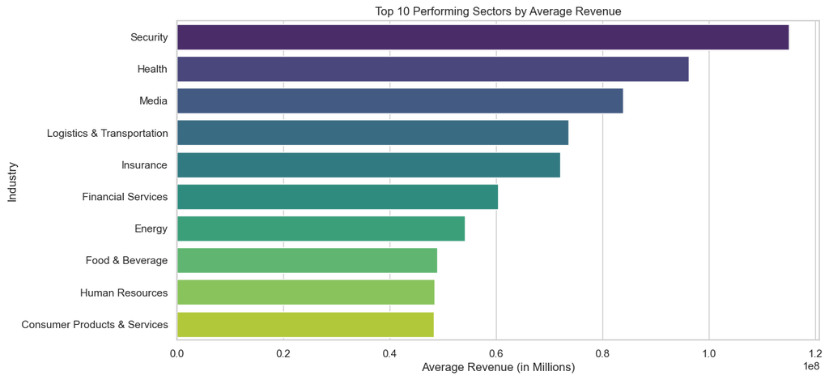

```python
import seaborn as sns
import matplotlib.pyplot as plt

# Calculate the average revenue for each industry
average_revenue_by_industry = df.groupby('INDUSTRY')['REVENUE'].mean().sort_values(ascending=False)

# Select the top 10 performing sectors by average revenue
top_10_performing_sectors = average_revenue_by_industry.head(10)

# Create a seaborn bar plot to visualize the top-performing sectors
plt.figure(figsize=(12, 6))
sns.set(style="whitegrid")  # Setting style
sns.barplot(x=top_10_performing_sectors.values, y=top_10_performing_sectors.index, palette="viridis")
plt.title('Top 10 Performing Sectors by Average Revenue')
plt.xlabel('Average Revenue (in Millions)')
plt.ylabel('Industry')
plt.show()
```

## Inference 2

From the above graph we can see that the companies in the 'Security' sector made the highest average revenue in comparison to the other sectors.

This could be beause from the year 2014 - 2017, there was a heightened awareness of security threats, both physical and digital. Events such as data breaches, cyberattacks, and global security issues contributed to a greater demand for security services.

This surge in demand for cybersecurity services led to a massive boost in the revenues of cybersecurity-focused security companies.

"I pledge on my honor that I have not given nor received any unauthorized assistance on this assignment."

-- Balaji Udayakumar